# Testing the relation between dispositional anthropomorphism and Theory-of-Mind network activation

Ruud Hortensius and Michaela Kent

#### Project AnThroM: experiment 1

June 2019 - July 2020

# 1. Details

## 1.1 Libraries

```r
source("R_rainclouds.R")
source("summarySE.R")
library("psych")
library("ordinal")
library("brms")
library("fs")
library("patchwork") #devtools::install_github("thomasp85/patchwork")
library("easystats") #devtools::install_github("easystats/easystats")
library("sjPlot")
library("httr")
library("tidyverse")
theme_set(theme_classic(base_size = 15))
options(mc.cores = parallel::detectCores()) #run on multiple cores)
```

Note: for the code chunk the language is listed, but all except for r chunks are executed in the terminal

## 1.2 Data description

Data of the Theory-of-Mind functional localiser and Individual Differences in Anthropomorphism Questionnaire are from five different studies.

Dataset_1: Bangor Imaging Unit; EMBOTS; *n*=29 (including 1 pilot scan); full dataset and publication: [Cross…Hortensius (2019) PTRB](https://royalsocietypublishing.org/doi/10.1098/rstb.2018.0034).

Dataset_2: Centre for Cognitive NeuroImaging; SHAREDBOTS; *n*=35 (including 2 pilot scans) publication: Hortensius & Cross, in preparation.

Dataset_3: Centre for Cognitive NeuroImaging; Two studies with the same parameters: *n*=22 (including 2 pilot scans). Social_Gradient_1; *n*=10 (pilot experiment) and BOLDlight; *n*=12.

Dataset_4: Centre for Cognitive NeuroImaging; GAMEBOTS; *n*=22.

Get info for table S1:

```r
#load data
DF.dataset1 <- read_tsv(file = "experiment1/dataset_1/participants.tsv")
DF.dataset2 <- read_tsv(file = "experiment1/dataset_2/participants.tsv")
DF.dataset3 <- read_tsv(file = "experiment1/dataset_3/participants.tsv")
DF.dataset4 <- read_tsv(file = "experiment1/dataset_4/participants.tsv")
#combine data
bind_rows(DF.dataset1, DF.dataset2, DF.dataset3,  DF.dataset4, .id = "dataset") %>%
  group_by(dataset) %>%
  summarise(mean = mean(age),
            sd = sd(age)) %>%
  knitr::kable(., "html", caption = "Age") %>%
  kable_styling("striped")
```

Age

| dataset | mean | sd |
| --- | --- | --- |
| 1 | 20.07 | 1.944 |
| 2 | 25.43 | 4.723 |
| 3 | 25.73 | 5.347 |
| 4 | 21.95 | 3.047 |

```r
bind_rows(DF.dataset1, DF.dataset2, DF.dataset3,  DF.dataset4, .id = "dataset") %>%
  group_by(dataset, sex) %>%
  tally() %>%
  knitr::kable(., "html", caption = "Sex") %>%
  kable_styling("striped")
```

Sex

| dataset | sex | n |
| --- | --- | --- |
| 1 | F | 20 |
| 1 | M | 9 |
| 2 | F | 22 |
| 2 | M | 13 |
| 3 | F | 12 |
| 3 | M | 10 |
| 4 | M | 22 |

## 1.3 Neuroimaging procedure

All participants completed a Theory-of-Mind localiser ([Jacoby et al., 2016](https://www.sciencedirect.com/science/article/pii/S1053811915010472); [Richardson et al. 2018](https://www.nature.com/articles/s41467-018-03399-2)) and an anatomical scan either in the same session or in two seperate sessions. During the localiser participants passively viewed a short 5.6 min animated film ([Partly Cloudy](https://www.pixar.com/partly-cloudy#partly-cloudy-1)). This movie includes scenes depicting pain (e.g. an alligator biting the main character) and events that trigger mentalizing (e.g. the main character revealing its intention). For dataset_3 and dataset_4 a fieldmap was collected as well. At the end of each experiment participants completed the Individual Differences in Anthropomorphism Questionnaire (IDAQ) ([Waytz et al., 2010](https://journals.sagepub.com/doi/full/10.1177/1745691610369336)).

- BOLD:  
  Dataset_1: 3x3x3.5mm voxels, 32 slices, repetition time = 2s, echo time = 30ms  
  Dataset_2: 3mm isotropic, 37 slices, TR = 2s, TE = 30ms  
  Dataset_3: 2mm isotropic, 68 slices, TR = 2s, TE = 26ms  
  Dataset_4: 2.75 x 2.75 x 4mm, 32 slices, TR = 2s, TE = 13 and 31ms
- T1W:  
  Dataset_1: 1mm isotropic resolution, TR = 12ms, TE = 3.47 / 5.15 / 6.83 / 8.52 / 10.20ms (SENSE)  
  Dataset_2 - 4: 1mm isotropic resolution, TR = 2.3s, TE = 29.6ms (ADNI)
- Fieldmaps:  
  Dataset_1: no, so –use-syn-sdc  
  Dataset_2: no, so –use-syn-sdc  
  Dataset_3: yes  
  Dataset_4: yes

# 2. BIDS dataset

## 2.1 Creating the BIDS dataset

For this you need HeuDiConv [Heuristic DICOM Converter](https://github.com/nipy/heudiconv).  
Based on the tutorial by [Franklin Feingold](http://reproducibility.stanford.edu/bids-tutorial-series-part-2a/).

Dowload the latest version of Heudiconv (we used 0.6.0.dev1):

```r
docker pull nipy/heudiconv:latest
```

If on the GRID do:

```r
singularity pull docker://nipy/heudiconv:latest
```

Create the info file (dataset_2 - 4):

```r
docker run --rm -it -v /Volumes/Project0255/:/base nipy/heudiconv:latest -d /base/dataset_3/sourcedata/sub-{subject}/*.IMA -o /base/dataset_3 -f convertall -s 315 -c none --overwrite
```

For dataset_1 we first need to convert the .dcm from jpeg-2000 lossless to uncompressed dcm (thanks to Michele Svanera for the code):

```r
python3 convert_all_compressed_dicom.py
```

Create the info file (dataset_1):

```r
docker run --rm -it -v /Volumes/Project0255/:/base nipy/heudiconv:latest -d /base/dataset_1/sourcedata/sub-{subject}/ses-{session}/*.dcm -o /base/dataset_1 -f convertall -s 129 -ss 01 -c none --overwrite
```

Get the info file:

```r
cp /Volumes/Project0255/code/.heudiconv/301/info/dicominfo.tsv /Volumes/Project0255/code
```

## 2.2 Create the heuristic file

Create the following python file and save it in the code folder. There is one functional task (func_movie) and one anatomical (t1w). Dataset_3 and 4 have a field map as well (fmap_phase and fmap_magnitude)

Create a heuristic to automatically convert the files:

```r
import os
def create_key(template, outtype=('nii.gz',), annotation_classes=None):
    if template is None or not template:
        raise ValueError('Template must be a valid format string')
    return template, outtype, annotation_classes
def infotodict(seqinfo):
    """Heuristic evaluator for determining which runs belong where
    allowed template fields - follow python string module:
    item: index within category
    subject: participant id
    seqitem: run number during scanning
    subindex: sub index within group
    session: session id (only for dataset_1)
    """

    t1w1 = create_key('sub-{subject}/{session}/anat/sub-{subject}_{session}_T1w')
    func_movie1 = create_key('sub-{subject}/{session}/func/sub-{subject}_{session}_task-movie_bold')

    t1w = create_key('sub-{subject}/anat/sub-{subject}_T1w')
    func_movie = create_key('sub-{subject}/func/sub-{subject}_task-movie_bold')
    func_movie_echo_1 = create_key('sub-{subject}/func/sub-{subject}_task-movie_echo-1_bold')
    func_movie_echo_2 = create_key('sub-{subject}/func/sub-{subject}_task-movie_echo-2_bold')
    fmap_phase = create_key('sub-{subject}/fmap/sub-{subject}_phasediff')
    fmap_magnitude = create_key('sub-{subject}/fmap/sub-{subject}_magnitude')

    info = {t1w1: [], func_movie1: [], t1w: [], func_movie: [], fmap_phase: [], fmap_magnitude: [],
            func_movie_echo_1: [], func_movie_echo_2: []}

    for idx, s in enumerate(seqinfo):
        if ('T1W_1mm_sag SENSE' in s.protocol_name):
            info[t1w1].append(s.series_id)
        if ('ToM_PartlyCloudy SENSE' in s.protocol_name):
            info[func_movie1].append(s.series_id)
        if ('t1_mpr_ns_sag_iso_ADNI_32ch' in s.protocol_name):
            info[t1w].append(s.series_id)
        if ('t1_mpr_ns_sag_P2_ADNI_32ch' in s.protocol_name):
            info[t1w].append(s.series_id)
        if (s.dim4 == 175) and ('FMRI_MB2_p2_2MMISO_TR2_movie' in s.protocol_name):
            info[func_movie].append(s.series_id)
        if (s.dim4 == 175) and ('FMRI_MB2_movie_p2_2MMISO_TR2' in s.protocol_name):
            info[func_movie].append(s.series_id)
        if (s.dim4 == 170) and ('ep2d_ToM_Loc' in s.protocol_name):
            info[func_movie].append(s.series_id)
        if (s.dim4 == 175) and ('ep2d_ToM_Loc' in s.protocol_name):
            info[func_movie].append(s.series_id)
        if (s.dim4 == 175) and ('ep2d_ToM_Loc_boldTR2' in s.protocol_name):
            info[func_movie].append(s.series_id)
        if (s.TE == 13) and ('BP_ep2d_multiecho_32ch_p3_TOM' in s.protocol_name):
            info[func_movie_echo_1].append(s.series_id)
        if (s.TE == 31.36) and ('BP_ep2d_multiecho_32ch_p3_TOM' in s.protocol_name):
            info[func_movie_echo_2].append(s.series_id)
        if (s.dim3 == 92) and ('gre_field_mapping_AAH' in s.protocol_name):
            info[fmap_magnitude].append(s.series_id)
        if (s.dim3 == 46) and ('gre_field_mapping_AAH' in s.protocol_name):
            info[fmap_phase].append(s.series_id)
        if (s.dim3 == 64) and ('gre_field_mapping_AAH' in s.protocol_name):
            info[fmap_magnitude].append(s.series_id)
        if (s.dim3 == 32) and ('gre_field_mapping_AAH' in s.protocol_name):
            info[fmap_phase].append(s.series_id)
    return info
```

Use the heuristic file to convert the Dicom files to .nii.gz (nifti) and create .json files:

```r
docker run --rm -it -v /Volumes/Project0255/:/base nipy/heudiconv:latest -d /base/dataset_4/sourcedata/sub-{subject}/*.IMA -o /base/dataset_4 -f /base/code/heuristic_anthrom.py -s 401 -c dcm2niix -b --overwrite
```

```r
docker run --rm -it -v /Volumes/Project0255/:/base nipy/heudiconv:latest -d /base/dataset_1/sourcedata/sub-{subject}/ses-{session}/*.dcm -o /base/dataset_1 -f /base/code/heuristic_anthrom.py -s 121 -ss 02 -c dcm2niix -b --overwrite
```

(Sub-116 was done manually in dcm2niigui): On the GRID Type in bash before running

Dataset_1:

```r
singularity run -B /analyse/Project0255/:/base /analyse/Project0255/my_images/heudiconv_latest.sif -d /base/dataset_1/sourcedata/sub-{subject}/ses-{session}/*.dcm -o /base/dataset_1/ -f /base/code/heuristic_anthrom.py -s 116 -ss 01 -c dcm2niix -b --overwrite
```

Dataset_2 - 4:

```r
singularity run -B /analyse/Project0255/:/base /analyse/Project0255/my_images/heudiconv_latest.sif -d /base/dataset_2/sourcedata/sub-{subject}/*.IMA -o /base/dataset_2/ -f /base/code/heuristic_anthrom.py -s 201 -c dcm2niix -b --overwrite
```

## 2.3 Anonymise the data

Deface using [Pydeface](https://github.com/poldracklab/pydeface):

```r
#!/bin/bash

set -e
####For loop that defaces the MRI per subject and replaces the old MRI with the new defaced MRI
rootfolder=/Volumes/Project0255/dataset_4

for subj in 401; do
    echo "Defacing participant $subj"
pydeface ${rootfolder}/sub-${subj}/anat/sub-${subj}_T1w.nii.gz
rm -f ${rootfolder}/sub-${subj}/anat/sub-${subj}_T1w.nii.gz
mv ${rootfolder}/sub-${subj}/anat/sub-${subj}_T1w_defaced.nii.gz ${rootfolder}/sub-${subj}/anat/sub-${subj}_T1w.nii.gz
done
```

For dataset_1: ses-01: 101 102 103 107 112 113 117 118 119 122 123 124 128 ses-02: 104 105 106 108 109 110 111 115 116 120 121 125 126 127

```r
#!/bin/bash

set -e
rootfolder=/Volumes/Project0255/dataset_1

for subj in 129; do
    echo "Defacing participant $subj"
for session in 01; do
for echo in 1 2 3 4 5; do
pydeface ${rootfolder}/sub-${subj}/ses-${session}/anat/sub-${subj}_ses-${session}_echo-${echo}_T1w.nii.gz
rm -f ${rootfolder}/sub-${subj}/ses-${session}/anat/sub-${subj}_ses-${session}_echo-${echo}_T1w.nii.gz
mv ${rootfolder}/sub-${subj}/ses-${session}/anat/sub-${subj}_ses-${session}_echo-${echo}_T1w_defaced.nii.gz ${rootfolder}/sub-${subj}/ses-${session}/anat/sub-${subj}_ses-${session}_echo-${echo}_T1w.nii.gz
done
done
done
```

## 2.4 Update the .json file for the fmaps for dataset_3 and dataset_4

You need to specify “IntendedFor” field in the _phasediff.json files to point which scans the estimated fieldmap should be applied to.

Run the following script (thanks to Michele Svanera for the code):

```r
python change_json.py
```

## 2.5 Combine the dual-echo runs for dataset_4

Dataset_4 used dual-echo acquisition, we need to combine the two echos in order to be able to use fmriprep (see [NeuroStar](https://neurostars.org/t/fmriprep-does-not-combine-multi-echo-timeseries/3398/2) for more info). We created a dual_sum volume by adding the two images together (see [Halai et al. 2014](https://onlinelibrary.wiley.com/doi/full/10.1002/hbm.22463)).

Run the following script (thanks to Tyler Morgan for the code):

```r
python sum_echo.py
```

## 2.6 Theory-of-Mind event protocols

Create tsv file for functional localiser. Event coding (in s; 10s of fixation before movie starts; accounting for haemodynamic lag) is based on Richardson et al. 2018 - reverse correlation analyses.

Note: For sub-322 the trigger was at the start of the movie (thus create a different tsv, with event - 10s). Check the triggers for dataset_1.

```r
PartlyCloudy <- data.frame(onset = c(86, 98, 120, 176, 238, 252, 300, 70, 92, 106, 136, 194, 210, 228, 262, 312), #create the events (same for every sub)
                           duration = c(4, 6, 4, 16, 6, 8, 6, 4, 2, 4, 10, 4, 12, 6, 6, 4),
                           trial_type = c(rep("mental",7), rep("pain",9)))

#dataset_1
for (sub in 102:129){ #note: localisers for sub-101 are in ses-02, see below
  filename = paste("/Volumes/Project0255/dataset_1/sub-", sub, "/ses-01/func/sub-", sub, "_ses-01_task-movie_events.tsv", sep ="")
  write.table(PartlyCloudy, file = filename, sep="\t", row.names = FALSE, quote = FALSE)
}

#write table for sub-101
write.table(PartlyCloudy, file = "/Volumes/Project0255/dataset_1/sub-101/ses-02/func/sub-101_ses-02_task-movie_events.tsv", sep="\t", row.names = FALSE, quote = FALSE)

#dataset_2
for (sub in 201:235){
  filename = paste("/Volumes/Project0255/dataset_2/sub-", sub, "/func/sub-", sub, "_task-movie_events.tsv", sep ="")
  write.table(PartlyCloudy, file = filename, sep="\t", row.names = FALSE, quote = FALSE)
}
#dataset_3
for (sub in 301:322){ #note: localisers for sub-322 should have t-10 (no trigger) <-manually correct this
  filename = paste("/Volumes/Project0255/dataset_3/sub-", sub, "/func/sub-", sub, "_task-movie_events.tsv", sep ="")
  write.table(PartlyCloudy, file = filename, sep="\t", row.names = FALSE, quote = FALSE)
}
#dataset_4
for (sub in 401:422){
  filename = paste("/Volumes/Project0255/dataset_4/sub-", sub, "/func/sub-", sub, "_task-movie_events.tsv", sep ="")
  write.table(PartlyCloudy, file = filename, sep="\t", row.names = FALSE, quote = FALSE)
}
```

## 2.6 BIDS validation

Use the BIDS-Validator to check if the dataset is BIDS compliant:

```r
docker run -ti --rm -v /Volumes/Project0255/dataset_4:/data:ro bids/validator /data
```

# 3. fMRI preprocessing

## 3.1 Run MRQIC

MRIQC is a docker tool to do quality control of the data. More info [here](https://poldracklab.github.io/mriqc/).

MRIQC 0.14.2 was used:

```r
docker run -it --rm -v /Volumes/Project0255/dataset_1/:/data:ro -v /Volumes/Project0255/dataset_1/derivatives/mriqc:/out poldracklab/mriqc:0.14.2 /data /out participant --participant-label 101 -m T1w bold --ica --fft-spikes-detector
```

On the GRID do (cd in /analyse folder):

```r
singularity run --cleanenv /analyse/Project0255/my_images/mriqc-0.14.2.simg /analyse/Project0255/dataset_1 /analyse/Project0255/dataset_1/derivatives/mriqc participant --participant-label 123 -m T1w bold --ica --fft-spikes-detector -w /analyse/Project0255/work
```

Run it seperately for the datasets. Change participant to group to create the group reports:

```r
docker run -it --rm -v /Volumes/Project0255/dataset_4/:/data:ro -v /Volumes/Project0255/dataset_4/derivatives/mriqc:/out poldracklab/mriqc:0.14.2 /data /out group
```

## 3.2 Compare MRIQC

Plot the output. This is based on [MRIQCeption](https://github.com/elizabethbeard/mriqception). The MRIQCeption Visualization by Catherine Walsh was adapted. Adjust the filter if you want to look at different measures.

Adjust this to your liking (e.g. bold: fd_mean, fd_perc, dvars_std, dvars_vstd, gcor, tsnr, t1w: cjv, cnr, snr, efc, inu, wm2max, fwhm) and modality (bold or t1w):

```r
QCmeasure <- "fd_mean"
modality <- "bold"
```

Run the following code. Change the script below to load the group results for the different datasets:

```r
#load data
DF.dataset1  <- read_tsv(file = paste("experiment1/dataset_1/derivatives/mriqc/group_", modality, ".tsv", sep ="")) %>%
  gather("measure", "value", 2:46) %>%
  select("bids_name","measure", "value")
```

[output not shown]

## 3.3 fMRIprep

fMRIprep is a docker tool for preprocessing of the fMRI data. More info [here](https://fmriprep.readthedocs.io/en/stable/#)

fMRIprep version 1.5.2 was used on a local iMac.

If you run into memory problems you can use –skip_bids_validation; skipped the –write-graph flag to save space, and –use-syn-sdc only for dataset_1 and datatset_2.

If run on the GRID, cd into the analyse folder and run:

```r
singularity run --cleanenv /analyse/Project0255/my_images/fmriprep-1.5.2.simg /analyse/Project0255/dataset_1/ /analyse/Project0255/dataset_1/derivatives participant --participant-label sub-129 --fs-license-file /analyse/Project0255/my_images/license.txt --skip_bids_validation --use-syn-sd --fs-no-reconall -w /analyse/Project0255/work/compute00
```

Resize functional files for two participants (sub-117 and sub-125) from dataset_1 (sub-{sub}_ses-01_task-movie_space-MNI152NLin2009cAsym_desc-preproc_bold.nii) to allow for group comparison (run this in MATLAB):

```
voxsiz = [3 3 3.5]; % new voxel size {mm}
V = spm_select([1 Inf],'image');
V = spm_vol(V);
for i=1:numel(V)
   bb        = spm_get_bbox(V(i));
   VV(1:2)   = V(i);
   VV(1).mat = spm_matrix([bb(1,:) 0 0 0 voxsiz])*spm_matrix([-1 -1 -1]);
   VV(1).dim = ceil(VV(1).mat \ [bb(2,:) 1]' - 0.1)';
   VV(1).dim = VV(1).dim(1:3);
   spm_reslice(VV,struct('mean',false,'which',1,'interp',0)); % 1 for linear
end
```

# 4. fMRI analyses

## 4.1 Example script for first-level analysis

Example MATLAB script (dataset 3):

```
%========================================================================
%     SPM first-level analysis for fmriprep data in BIDS format
%========================================================================
%     This script is written by Ruud Hortensius and Michaela Kent
%     (University of Glasgow). Based upon a script written by
%     Shengdong Chen (ACRLAB) and Stephan Heunis (TU Eindhoven).
%
%     Added: loop for runs
%     Parameters as specified by Saxelab: https://saxelab.mit.edu/theory-mind-and-pain-matrix-localizer-movie-viewing-experiment
%
%     Last updated: January 2020
%========================================================================

clear all

%% Inputdirs
BIDS = spm_BIDS('/Volumes/Project0255/dataset_3/'); % Parse BIDS directory (easier to query info from dataset)
BIDSpreproc=fullfile(BIDS.dir,'derivatives/fmriprep'); % get the preprocessed directory

%sublist = spm_BIDS(BIDS,'subjects') %number of subjects
sublist = transpose(BIDS.participants.participant_id) %get subject list including the 'sub'
subex = []
sublist(subex) = []; %update the subjects

taskid='movie'; %specify the task to be analysed

numScans=175;  %The number of volumes per run <---

TR = 2;     % Repetition time, in seconds <---
unit='secs'; % onset times in secs (seconds) or scans (TRs)

%% Outputdirs
outputdir=fullfile(BIDS.dir,'derivatives/bids_spm/first_level');  % root outputdir for sublist
spm_mkdir(outputdir,char(sublist), char(taskid)); % create output directory

%% Loop for sublist
spm('Defaults','fMRI'); %Initialise SPM fmri
spm_jobman('initcfg');  %Initialise SPM batch mode

for i=1:length(sublist)
```

[output cut: 73 more lines]

```
    matlabbatch{2}.spm.stats.fmri_est.method.Classical = 1;

    %% Contrasts
    matlabbatch{3}.spm.stats.con.spmmat = {[subdir filesep 'SPM.mat']};
    % Set contrasts of interest.
    matlabbatch{3}.spm.stats.con.consess{1}.tcon.name = 'mental_pain';
    matlabbatch{3}.spm.stats.con.consess{1}.tcon.convec = [1 -1 0 0 0 0 0 0 0 0 0 0 0 0 0];
    matlabbatch{3}.spm.stats.con.consess{2}.tcon.name = 'pain_mental';
    matlabbatch{3}.spm.stats.con.consess{2}.tcon.convec = [-1 1 0 0 0 0 0 0 0 0 0 0 0 0 0];
    matlabbatch{3}.spm.stats.con.delete = 0;

    %% Run matlabbatch jobs
    spm_jobman('run',matlabbatch);

end
```

## 4.2 First-level analysis

Run the following commands in the terminal.

Dataset_1:

```r
cd "/Volumes/Project0255/code/"
matlab -batch "BIDS_SPM_firstlevel_tom_dataset1"
matlab -batch "BIDS_SPM_firstlevel_tom_dataset1_ppn101"
matlab -batch "BIDS_SPM_firstlevel_tom_dataset1_ppn114"
```

Dataset_2:

```r
cd "/Volumes/Project0255/code/"
matlab -batch "BIDS_SPM_firstlevel_tom_dataset2_ppn201_202"
```

Dataset_3:

```r
cd "/Volumes/Project0255/code/"
matlab -batch "BIDS_SPM_firstlevel_tom_dataset3"
```

Dataset_4:

```r
cd "/Volumes/Project0255/code/"
matlab -batch "BIDS_SPM_firstlevel_tom_dataset4"
```

## 4.4 Example script for second-level whole-brain analysis

clear all

%nsession = spm_BIDS(BIDS,‘sessions’) %how many sessions? careful, sometimes collapsing across sessions not wanted %sessionid = ‘ses-01’ %get session id

taskid=‘movieHC’; %specify the task to be analysed

contrast=‘con_0001’; %specify the contrast to be analysed contrast_name=‘mental_hc’; %specify the name of the contrast

smoothing = 1; %soomthing of first-level contrasts (1=yes, 0=no) s_kernel = [5 5 5]

%% Outputdirs outputdir=fullfile(BIDS.dir,‘derivatives/bids_spm/second_level’, char(contrast_name)); % root outputdir for sublist spm_mkdir(outputdir); % create output directory

spm(‘Defaults’,‘fMRI’); %Initialise SPM fmri spm_jobman(‘initcfg’); %Initialise SPM batch mode

```
clear matlabbatch
```

end

%% Load the contrasts matlabbatch{1}.spm.stats.factorial_design.dir = {outputdir};

%% Model estimation matlabbatch{2}.spm.stats.fmri_est.spmmat = {[outputdir filesep ‘SPM.mat’]}; matlabbatch{2}.spm.stats.fmri_est.write_residuals = 0; matlabbatch{2}.spm.stats.fmri_est.method.Classical = 1;

%% Run matlabbatch jobs spm_jobman(‘run’,matlabbatch);

[output not shown]

## 4.6 ToM ROI analysis

contrastid = ‘mental’ %can be either mental (vs. pain) or pain (vs. mental) networkid = ‘tom’ %can be either tom (theory-of-mind) or pain (pain matrix)

%% Outputdirs outputdir=fullfile(BIDS.dir,‘derivatives/roi’, networkid); % root outputdir for sublist spm_mkdir(outputdir); % create output directory

%% Load design matrix spm_name = spm_load(fullfile(BIDSsecond, filesep, contrastid , ‘SPM.mat’)) D = mardo(spm_name);

## 4.7 Custom steps

Add sub-201 and sub-202 to get the ROI data (different parameters, not included in the whole-brain analysis):

```r
cd "/Volumes/Project0255/code/"
matlab -batch "BIDS_SPM_secondlevel_tom_dataset2_201_202"
matlab -batch "ROI_extract_201_202"
```

# 5. IDAQ

## 5.1 Calculation of individual scores:

Dataset 2: sub-206-212, 219, 221-22, 224-25, 228, 231, 233-34 completed a version with the scale ranging from 1-10 instead of 0-10. Analyses should be run with and without these participants:

```r
sub_ex = c(206:212, 219, 221:222, 224:225, 228, 231, 233:234)
```

Get the IDAQ data for all the participants:

```r
#load data
DF.d1  <- read_csv(file = "experiment1/dataset_1/derivatives/IDAQ_dataset1.csv") %>%
  gather("sub", "value", 4:32)
DF.d2  <- read_csv(file = "experiment1/dataset_2/derivatives/IDAQ_dataset2.csv") %>%
  gather("sub", "value", 4:38)
DF.d3  <- read_csv(file = "experiment1/dataset_3/derivatives/IDAQ_dataset3.csv") %>%
  gather("sub", "value", 4:25)
DF.d4  <- read_csv(file = "experiment1/dataset_4/derivatives/IDAQ_dataset4.csv") %>%
  gather("sub", "value", 4:25)
DF.idaq <- bind_rows(DF.d1, DF.d2, DF.d3, DF.d4, .id = "dataset") %>%
  mutate(sub=gsub('sub-','',sub))%>%
  transform(sub=as.integer(sub)) %>%
  mutate(scale = as.factor(ifelse(scale == "IDAQ-NA", "IDAQNA", "IDAQ")))
rm(DF.d1, DF.d2, DF.d3, DF.d4)
```

## 5.2 Reliability of IDAQ

Check the reliability of the IDAQ scale:

```r
DF.idaq %>%
  filter(scale == "IDAQ") %>%
  #filter(!sub %in% sub_ex) %>%
  select(-scale, -subscale)  %>%
  spread(itemnr, value) %>%
  select(-sub, -dataset) %>%
  psych::alpha(na.rm = TRUE)
```

```
Reliability analysis
Call: psych::alpha(x = ., na.rm = TRUE)
```

|  | raw_alpha | std.alpha | G6(smc) | average_r | S/N | ase | mean | sd | median_r |
| --- | --- | --- | --- | --- | --- | --- | --- | --- | --- |
|  | 0.8018188 | 0.8059196 | 0.869336 | 0.2168126 | 4.152503 | 0.0279359 | 3.37716 | 1.220938 | 0.2225996 |

```
 lower alpha upper     95% confidence boundaries
0.75 0.8 0.86

 Reliability if an item is dropped:
```

|  | raw_alpha | std.alpha | G6(smc) | average_r | S/N | alpha se | var.r | med.r |
| --- | --- | --- | --- | --- | --- | --- | --- | --- |
| 3 | 0.8008165 | 0.8005013 | 0.8659411 | 0.2227647 | 4.012563 | 0.02792102 | 0.03623875 | 0.2220538 |
| 4 | 0.7966431 | 0.8014683 | 0.8626917 | 0.2238168 | 4.036979 | 0.02866179 | 0.03486754 | 0.2349564 |
| 7 | 0.7903914 | 0.7935482 | 0.8610129 | 0.2154114 | 3.843746 | 0.02955790 | 0.03784650 | 0.2220538 |
| 9 | 0.8007014 | 0.8056312 | 0.8680556 | 0.2284316 | 4.144859 | 0.02823977 | 0.03536785 | 0.2313872 |
| 11 | 0.7891601 | 0.7916458 | 0.8540051 | 0.2134619 | 3.799519 | 0.02963468 | 0.03700100 | 0.2220538 |
| 12 | 0.7933584 | 0.7986124 | 0.8618125 | 0.2207308 | 3.965550 | 0.02917592 | 0.03527852 | 0.2349564 |
| 13 | 0.7950629 | 0.7960448 | 0.8576560 | 0.2180098 | 3.903039 | 0.02905811 | 0.03585534 | 0.2225996 |
| 14 | 0.7890742 | 0.7922248 | 0.8585794 | 0.2140525 | 3.812894 | 0.02980103 | 0.03796862 | 0.2313872 |
| 17 | 0.7979578 | 0.8017226 | 0.8621148 | 0.2240947 | 4.043440 | 0.02847331 | 0.03352406 | 0.2220538 |
| 20 | 0.7900845 | 0.7976290 | 0.8535666 | 0.2196827 | 3.941420 | 0.02967244 | 0.03101681 | 0.2313872 |

[output cut: 5 more lines]

```
 Item statistics
```

|  | n | raw.r | std.r | r.cor | r.drop | mean | sd |
| --- | --- | --- | --- | --- | --- | --- | --- |
| 3 | 108 | 0.4502850 | 0.4490575 | 0.3852785 | 0.3096151 | 2.9814815 | 2.932198 |
| 4 | 108 | 0.4761460 | 0.4367515 | 0.3888935 | 0.3444865 | 5.8518519 | 2.730290 |
| 7 | 108 | 0.5081932 | 0.5350649 | 0.4862201 | 0.4153881 | 1.2222222 | 2.150129 |
| 9 | 108 | 0.3373812 | 0.3827749 | 0.3137074 | 0.2470516 | 0.8611111 | 1.831492 |
| 11 | 106 | 0.5306940 | 0.5578673 | 0.5281543 | 0.4301568 | 2.2735849 | 2.299205 |
| 12 | 108 | 0.4990623 | 0.4728472 | 0.4267299 | 0.3830816 | 6.0185185 | 2.730860 |
| 13 | 108 | 0.4564611 | 0.5046724 | 0.4672320 | 0.3806849 | 0.6481481 | 1.313587 |
| 14 | 107 | 0.5323490 | 0.5509594 | 0.5095279 | 0.4302201 | 1.7850467 | 2.414688 |
| 17 | 108 | 0.3952449 | 0.4335005 | 0.3868829 | 0.2980930 | 1.9907407 | 1.978838 |
| 20 | 108 | 0.5111925 | 0.4851053 | 0.4698563 | 0.4256332 | 7.7407407 | 1.982967 |

[output cut: 5 more lines]

## 5.3 Reliability of IDAQ-NA

Check the reliability of the IDAQ-NA scale:

```r
DF.idaq %>%
  filter(scale == "IDAQNA") %>%
  filter(!sub %in%  sub_ex) %>%
  select(-scale, -subscale)  %>%
  spread(itemnr, value) %>%
  select(-sub, -dataset) %>%
  psych::alpha(na.rm = TRUE)
```

```
Reliability analysis
Call: psych::alpha(x = ., na.rm = TRUE)
```

|  | raw_alpha | std.alpha | G6(smc) | average_r | S/N | ase | mean | sd | median_r |
| --- | --- | --- | --- | --- | --- | --- | --- | --- | --- |
|  | 0.6179246 | 0.619652 | 0.690329 | 0.09797069 | 1.629171 | 0.05721889 | 6.070393 | 0.961106 | 0.08204914 |

```
 lower alpha upper     95% confidence boundaries
0.51 0.62 0.73

 Reliability if an item is dropped:
```

|  | raw_alpha | std.alpha | G6(smc) | average_r | S/N | alpha se | var.r | med.r |
| --- | --- | --- | --- | --- | --- | --- | --- | --- |
| 1 | 0.5855953 | 0.5927513 | 0.6639523 | 0.09417370 | 1.455502 | 0.06231816 | 0.01881155 | 0.08172151 |
| 2 | 0.6220373 | 0.6246172 | 0.6892141 | 0.10622785 | 1.663948 | 0.05665858 | 0.01950141 | 0.10150943 |
| 5 | 0.5718907 | 0.5775043 | 0.6499557 | 0.08895022 | 1.366888 | 0.06452429 | 0.01771773 | 0.07991834 |
| 6 | 0.5990441 | 0.5990722 | 0.6709461 | 0.09643693 | 1.494215 | 0.06020368 | 0.01913626 | 0.08172151 |
| 8 | 0.6255201 | 0.6336783 | 0.7008033 | 0.10997192 | 1.729841 | 0.05652865 | 0.01920894 | 0.10477950 |
| 10 | 0.5837371 | 0.5869012 | 0.6513557 | 0.09213110 | 1.420729 | 0.06233876 | 0.01759770 | 0.07991834 |
| 15 | 0.6408126 | 0.6332907 | 0.6976998 | 0.10980866 | 1.726956 | 0.05351211 | 0.01869036 | 0.10477950 |
| 16 | 0.5722525 | 0.5690226 | 0.6488569 | 0.08618019 | 1.320307 | 0.06421475 | 0.01853958 | 0.07641402 |
| 18 | 0.5765022 | 0.5800579 | 0.6567170 | 0.08980271 | 1.381281 | 0.06391357 | 0.01913387 | 0.07802135 |
| 19 | 0.6034060 | 0.6010430 | 0.6718934 | 0.09715488 | 1.506536 | 0.05946425 | 0.01976668 | 0.07991834 |

[output cut: 5 more lines]

```
 Item statistics
```

|  | n | raw.r | std.r | r.cor | r.drop | mean | sd |
| --- | --- | --- | --- | --- | --- | --- | --- |
| 1 | 92 | 0.5022522 | 0.4555571 | 0.40006169 | 0.32647903 | 4.641304 | 2.948576 |
| 2 | 92 | 0.2637715 | 0.2716440 | 0.16012053 | 0.10722933 | 6.782609 | 2.329109 |
| 5 | 92 | 0.5520837 | 0.5352530 | 0.51186770 | 0.42055457 | 5.336957 | 2.410039 |
| 6 | 92 | 0.3902430 | 0.4210264 | 0.35055985 | 0.26989040 | 7.793478 | 1.890044 |
| 8 | 92 | 0.2033986 | 0.2145198 | 0.07486183 | 0.06349463 | 4.467391 | 2.024309 |
| 10 | 92 | 0.5001412 | 0.4867215 | 0.46382656 | 0.33997926 | 3.967391 | 2.703076 |
| 15 | 92 | 0.2649712 | 0.2170107 | 0.08842175 | 0.05441752 | 2.173913 | 3.097708 |
| 16 | 92 | 0.5630785 | 0.5775159 | 0.55118538 | 0.44379287 | 8.250000 | 2.136162 |
| 18 | 92 | 0.5462211 | 0.5222463 | 0.47744834 | 0.36711227 | 5.934783 | 3.130159 |
| 19 | 92 | 0.3513635 | 0.4100725 | 0.33488823 | 0.24402100 | 8.163043 | 1.659320 |

[output cut: 5 more lines]

## 5.4 IDAQ per subject

Calculate the IDAQ per subject:

```r
DF.idaq <- DF.idaq %>%
  dplyr::group_by(sub,dataset, scale) %>%
  dplyr::summarise(score = sum(value, na.rm = TRUE)) %>%
  ungroup()%>%
  mutate_at(vars(-score),as.factor)
```

## 5.5 Visualise the scores

Visualise the scores across the datasets and scales (Figure S1):

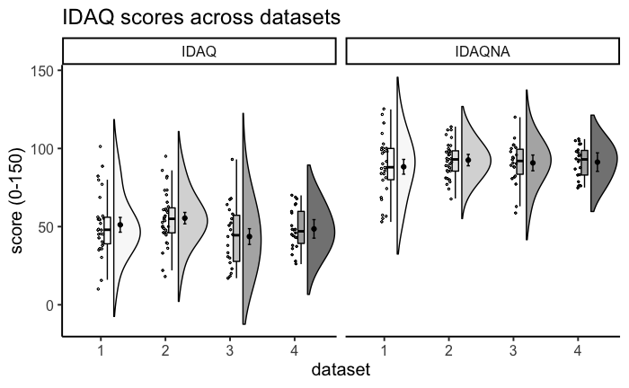

```r
idaq_sum <- summarySEwithin(DF.idaq, measurevar="score", betweenvars="dataset", withinvars= "scale", idvar="sub")
FS1 <- DF.idaq %>%
  group_by(sub,dataset, scale) %>%
  ggplot(.,aes(x=dataset,y=score,fill=dataset, group = dataset))+
  geom_flat_violin(position=position_nudge(x = .2, y = 0),adjust =2, trim = FALSE, alpha = .75, colour = "Black") +
  geom_point(aes(colour = dataset), position=position_jitter(width = .05), size = .5, shape = 21, colour = "Black") +
  geom_boxplot(aes(x=dataset,y=score),position=position_nudge(x = .1, y = 0),outlier.shape = NA, alpha = .5, width = .1, colour = "black") +
  geom_point(data = idaq_sum, aes(x = dataset, y = score), position = position_nudge(.3), colour = "BLACK")+
  geom_errorbar(data = idaq_sum, aes(x=dataset,y=score, ymin = score-ci, ymax = score+ci), position=position_nudge(x = .3, y = 0), width = .05)+
  scale_fill_brewer(palette = "Greys") +
  scale_colour_brewer(palette = "Greys") +
  ylab(paste("score (0-150)")) +
  ggtitle(paste("IDAQ scores across datasets")) +
  theme(legend.position="none") +
  facet_wrap(~scale)
FS1
ggsave("experiment1/figures/S1.TIFF", plot = FS1, width = 24.7, height = 15.24, units = "cm", dpi = 300)
```

Visualise the scores for IDAQ scale only (Figure 1A):

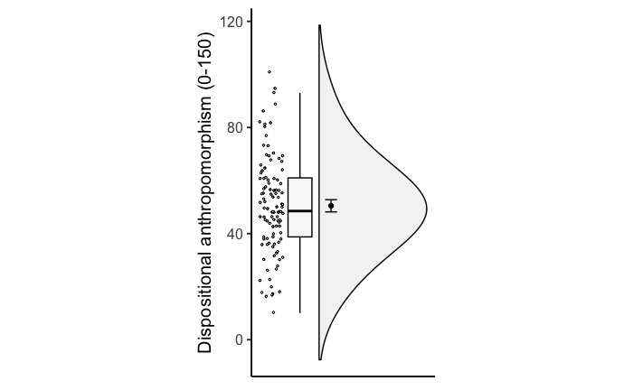

```r
idaq_sum <- summarySEwithin(DF.idaq, measurevar="score", withinvars= "scale", idvar="sub")

F1A <- DF.idaq %>%
  filter(scale == "IDAQ") %>%
  group_by(sub) %>%
  ggplot(.,aes(x = 1, y=score, fill = "Black"))+
  geom_flat_violin(position=position_nudge(x = .2, y = 0),adjust =2, trim = FALSE, alpha = .75, colour = "Black") +
  geom_point(aes(colour = dataset), position=position_jitter(width = .05), size = .5, shape = 21, colour = "Black") +
  geom_boxplot(aes(x=1,y=score),position=position_nudge(x = .12, y = 0),outlier.shape = NA, alpha = .5, width = .1, colour = "black") +
  geom_point(data = idaq_sum %>% filter(scale == "IDAQ"), aes(x = 0.95, y = score), position = position_nudge(.3), colour = "BLACK")+
  geom_errorbar(data = idaq_sum %>% filter(scale == "IDAQ"), aes(x=0.95,y=score, ymin = score-ci, ymax = score+ci), position=position_nudge(x = .3, y = 0), width = .05)+
  scale_fill_brewer(palette = "Greys") +
  scale_colour_brewer(palette = "Greys") +
  #theme_classic() +
  coord_fixed(ratio = 1/90) +
  ylab(paste("Dispositional anthropomorphism (0-150)")) +
  #ggtitle(paste("Dispositional anthropomorphism")) +
  theme(legend.position="none") +
  theme(
    axis.title.x = element_blank(),
    axis.text.x = element_blank(),
    axis.ticks.x = element_blank()

  )
F1A
ggsave("experiment1/figures/F1A.TIFF", plot = F1A, width = 24.7, height = 15.24, units = "cm", dpi = 300)
```

## 5.6 Median and interquartile range per dataset

Calculate the median IQR per dataset (table S2):

```r
DF.idaq %>%
  #filter(!sub %in%  sub_ex) %>%
  dplyr::group_by(scale,dataset) %>%
  dplyr::summarise(median = median(score),
            iqr = IQR(score))
```

| scale | dataset | median | iqr |
| --- | --- | --- | --- |
| IDAQ | 1 | 48.0 | 17.00 |
| IDAQ | 2 | 55.0 | 16.00 |
| IDAQ | 3 | 44.5 | 29.50 |
| IDAQ | 4 | 47.0 | 20.50 |
| IDAQNA | 1 | 88.0 | 20.00 |
| IDAQNA | 2 | 93.0 | 13.00 |
| IDAQNA | 3 | 92.0 | 16.00 |
| IDAQNA | 4 | 93.0 | 15.75 |

# 6. ROI results

## 6.1 Data wrangling

Create function to load the data for the different networks:

```r
roi_extract <- function(datasetno, substart, subend, network, nroi) {

  dir_ls(paste("experiment1/dataset_", datasetno, "/derivatives/roi/", network, sep = ""), regexp = "\\.tsv$") %>%
    map_dfr(read.delim, sep = "\t", .id = "id", header = FALSE)  %>%
    mutate(dataset = datasetno) %>%
    mutate(network = network) %>%
    mutate(network = str_extract(network, "tom|pain")) %>%
    mutate(id = str_extract(id, "dmpfc|mmpfc|vmpfc|ltpj|rtpj|prec|amcc|lmfg|rmfg|ls2|rs2|linsula|rinsula")) %>%
    dplyr::rename(roi = id, contrast = V1) %>%
    mutate(sub = rep(substart:subend, times=nroi, each=1)) %>%
    select(5,3,4,1:2)
}
```

Load the data for the Theory-of-Mind network:

```r
DF.d1 <- roi_extract(1, 101, 129, "tom", 6)
DF.d2.a <- roi_extract(2, 201, 202, "tom/201_202", 6)
DF.d2.b <- roi_extract(2, 203, 235, "tom", 6)
DF.d3 <- roi_extract(3, 301, 322, "tom", 6)
DF.d4 <- roi_extract(4, 401, 422, "tom", 6)
DF.temp <- bind_rows(DF.d1, DF.d2.a, DF.d2.b, DF.d3, DF.d4)
```

Load the data for the Pain Matrix:

```r
DF.d1 <- roi_extract(1, 101, 129, "pain", 7)
DF.d2.a <- roi_extract(2, 201, 202, "pain/201_202/", 7)
DF.d2.b <- roi_extract(2, 203, 235, "pain", 7)
DF.d3 <- roi_extract(3, 301, 322, "pain", 7)
DF.d4 <- roi_extract(4, 401, 422, "pain", 7)
DF.roi <- bind_rows(DF.temp, DF.d1, DF.d2.a, DF.d2.b, DF.d3, DF.d4)
rm(DF.d1, DF.d2.a, DF.d2.b, DF.d3, DF.d4, DF.temp)
```

Reorder ROI names for plots:

```r
order <- c("rtpj", "ltpj", "prec", "vmpfc","mmpfc","dmpfc", "rs2", "ls2", "rinsula", "linsula", "rmfg", "lmfg", "amcc")
DF.roi <- DF.roi %>%
  mutate_at(vars(-contrast),as.factor) %>%
  group_by(sub, dataset) %>%
  mutate(roi = fct_relevel(roi, order))
```

## 6.2 Theory-of-Mind network activation across datasets:

Plot the ToM activity across regions and datasets (Figure S2):

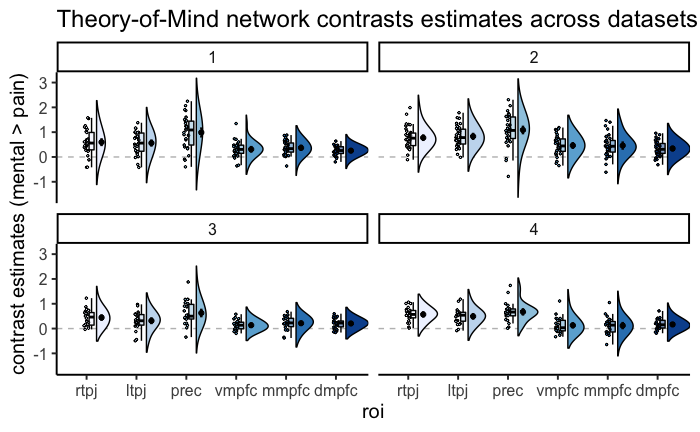

```r
roi_sum <- summarySEwithin(DF.roi, measurevar="contrast", betweenvars="dataset", withinvars= c("roi","network"), idvar="sub")
FS2 <- DF.roi %>%
  filter(network == "tom") %>%
  ggplot(.,aes(x=roi,y=contrast,fill=roi))+
  geom_hline(yintercept = 0, color = "grey", linetype = 2) +
  geom_flat_violin(position=position_nudge(x = .2, y = 0),adjust =2, trim = FALSE, colour = "Black") +
  geom_point(aes(colour = roi, fill = roi), position=position_jitter(width = .05), size = .5, shape = 21, colour = "Black") +
  geom_boxplot(aes(x=roi,y=contrast),position=position_nudge(x = .1, y = 0),outlier.shape = NA, alpha = .5, width = .1, colour = "black") +
  geom_point(data = roi_sum %>% filter(network == "tom"), aes(x = roi, y = contrast), position = position_nudge(.3), colour = "BLACK")+
  geom_errorbar(data = roi_sum %>% filter(network == "tom"), aes(x=roi,y=contrast, ymin = contrast-ci, ymax = contrast+ci), position=position_nudge(x = .3, y = 0), width = .05)+
  #theme_classic() +
  ylab(paste("contrast estimates (mental > pain)")) +
  scale_fill_brewer(palette = "Blues") +
  scale_colour_brewer(palette = "Blues") +
  ggtitle(paste("Theory-of-Mind network contrasts estimates across datasets and regions")) +
  theme(legend.position="none") +
  facet_wrap(~dataset)
FS2
ggsave("experiment1/figures/S2.TIFF", plot = FS2, width = 24.7, height = 15.24, units = "cm", dpi = 300)
```

Plot the ToM activity across regions (Figure 1C):

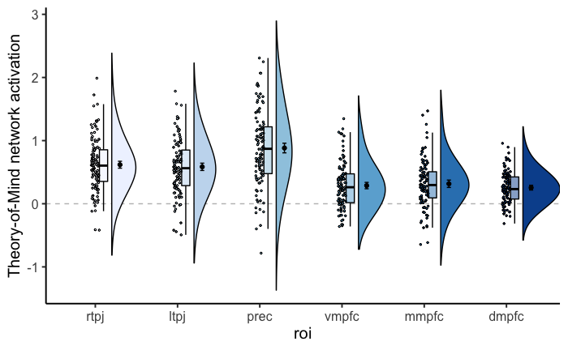

```r
roi_sum <- summarySEwithin(DF.roi, measurevar="contrast", withinvars= c("roi","network"), idvar="sub")
F1C <- DF.roi %>%
  filter(network == "tom") %>%
  ggplot(.,aes(x=roi,y=contrast,fill=roi))+
  geom_hline(yintercept = 0, color = "grey", linetype = 2) +
  geom_flat_violin(position=position_nudge(x = .2, y = 0),adjust =2, trim = FALSE, colour = "Black") +
  geom_point(aes(colour = roi, fill = roi), position=position_jitter(width = .05), size = .5, shape = 21, colour = "Black") +
  geom_boxplot(aes(x=roi,y=contrast),position=position_nudge(x = .1, y = 0),outlier.shape = NA, alpha = .5, width = .1, colour = "black") +
  geom_point(data = roi_sum %>% filter(network == "tom"), aes(x = roi, y = contrast), position = position_nudge(.3), colour = "BLACK")+
  geom_errorbar(data = roi_sum %>% filter(network == "tom"), aes(x=roi,y=contrast, ymin = contrast-ci, ymax = contrast+ci), position=position_nudge(x = .3, y = 0), width = .05)+
  #theme_classic() +
  ylab(paste("Theory-of-Mind network activation")) +
  scale_fill_brewer(palette = "Blues") +
  scale_colour_brewer(palette = "Blues") +
  #ggtitle(paste("Theory-of-Mind network contrasts estimates across datasets and regions")) +
  theme(legend.position="none")
F1C
ggsave("experiment1/figures/F1C.TIFF", plot = F1C, width = 24.7, height = 15.24, units = "cm", dpi = 300)
```

## 6.3 Pain Matrix activation across datasets

Plot the Pain Matrix activity across regions and datasets (Figure S3):

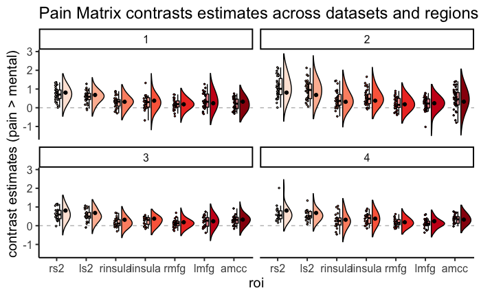

```r
FS3 <- DF.roi %>%
  filter(network == "pain") %>%
  ggplot(.,aes(x=roi,y=contrast,fill=roi))+
  geom_hline(yintercept = 0, color = "grey", linetype = 2) +
  geom_flat_violin(position=position_nudge(x = .2, y = 0),adjust =2, trim = FALSE, colour = "Black") +
  geom_point(aes(colour = roi, fill = roi), position=position_jitter(width = .05), size = .5, shape = 21, colour = "Black") +
  geom_boxplot(aes(x=roi,y=contrast),position=position_nudge(x = .1, y = 0),outlier.shape = NA, alpha = .5, width = .1, colour = "black") +
  geom_point(data = roi_sum %>% filter(network == "pain"), aes(x = roi, y = contrast), position = position_nudge(.3), colour = "BLACK")+
  geom_errorbar(data = roi_sum %>% filter(network == "pain"), aes(x=roi,y=contrast, ymin = contrast-ci, ymax = contrast+ci), position=position_nudge(x = .3, y = 0), width = .05)+
  #theme_classic() +
  ylab(paste("contrast estimates (pain > mental)")) +
  scale_fill_brewer(palette = "Reds") +
  scale_colour_brewer(palette = "Reds") +
  ggtitle(paste("Pain Matrix contrasts estimates across datasets and regions")) +
  theme(legend.position="none") +
  facet_wrap(~dataset)
FS3
ggsave("experiment1/figures/S3.TIFF", plot = FS3, width = 24.7, height = 15.24, units = "cm", dpi = 300)
```

## 6.5 Combine IDAQ scores and ROI data:

Create one DF:

```r
DF.roi <- DF.idaq %>%
  group_by(sub,dataset, scale) %>%
  ungroup() %>%
  left_join(DF.roi, DF.idaq, by = c("sub","dataset"), keep = FALSE) %>%
  pivot_wider(names_from=scale, values_from = score) #
```

Center the variables for the formal analysis:

```r
DF.roi$cent_IDAQNA <- scale(DF.roi$IDAQNA, scale = TRUE)
DF.roi$cent_IDAQ <- scale(DF.roi$IDAQ, scale = TRUE)
DF.roi <- DF.roi %>% group_by(roi) %>% mutate(cent_contrast = scale(contrast, scale =TRUE)) #scale per roi (analyses are done per roi)
```

# 7. IDAQ scores and ToM activity

## 7.1 Plot ToM and IDAQ

Create scatterplots with linear and non-linear lines for ToM network:

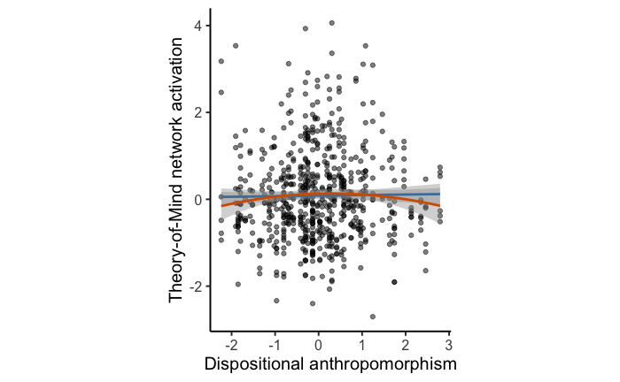

```r
F1D <- DF.roi %>%
  filter(network == "tom") %>%
  ggplot(aes(x=cent_IDAQ, y=cent_contrast)) +
  geom_point(alpha=0.5,show.legend = FALSE) +
  geom_smooth(method="lm", formula=y ~ x, se=TRUE, show.legend = FALSE, colour="#0072B2") +
  geom_smooth(method="lm", formula=y ~ x+ I(x^2), se=TRUE, show.legend=FALSE, colour = "#D55E00") +
  coord_fixed(ratio = 1/1) +
  labs(
    x="Dispositional anthropomorphism",
    y="Theory-of-Mind network activation"
  ) #+ theme_classic()
F1D
ggsave("experiment1/figures/F1D.TIFF", plot = F1D, width = 24.7, height = 15.24, units = "cm", dpi = 300)
```

Create scatterplots with linear and non-linear lines for individual regions of ToM network:

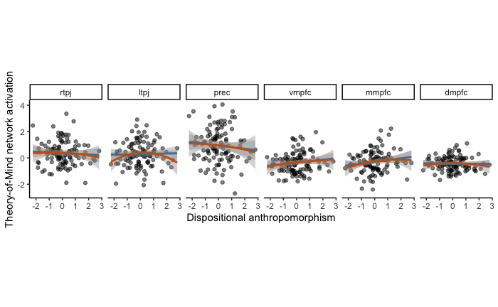

```r
F1E <- DF.roi %>%
  filter(network == "tom") %>%
  ggplot(aes(x=cent_IDAQ, y=cent_contrast)) +
  geom_point(alpha=0.5,show.legend = FALSE) +
  geom_smooth(method="lm", formula=y ~ x, se=TRUE, show.legend = FALSE, colour="#0072B2") +
  geom_smooth(method="lm", formula=y ~ x+ I(x^2), se=TRUE, show.legend=FALSE, colour = "#D55E00") +
  coord_fixed(ratio = 1/1) +
  facet_wrap(~roi, ncol = 6) +
  labs(
    x="Dispositional anthropomorphism",
    y="Theory-of-Mind network activation"
  ) + theme_classic()
F1E
ggsave("experiment1/figures/F1E.TIFF", plot = F1E, width = 24.7, height = 15.24, units = "cm", dpi = 300)
```

## 7.2 Create a function for the Bayesian regression models:

For the formal analysis we will test a linear and quadratic relationship between IDAQ and ToM network activity:

```r
DF.roi$cent_IDAQ2 <- DF.roi$cent_IDAQ^2
```

We run the models with uninformative (default) priors and create a function to run it for each region separately:

```r
reg_model <- function(region){
  brm(formula = cent_contrast ~ cent_IDAQ + cent_IDAQ2,
      data = DF.roi %>% filter(roi == region),
      family = gaussian,
      chains = 4,
      iter = 4000,
      seed = 42, #so the model is reproducible
      file = paste0("experiment1/models/regions/", region, ".RDS", sep = ""))
}
```

## 7.3 Run the ToM regression models:

Run the models for the ToM network first. It will load the model if it is already calculated:

```r
rtpj <- reg_model("rtpj")
ltpj <- reg_model("ltpj")
prec <- reg_model("prec")
vmpfc <- reg_model("vmpfc")
mmpfc <- reg_model("mmpfc")
dmpfc <- reg_model("dmpfc")
```

Get the summaries (verbatim, run individually):

```r
summary(rtpj)
summary(ltpj)
summary(prec)
summary(vmpfc)
summary(mmpfc)
summary(dmpfc)
```

## 7.4 ToM model output:

Use sjPlot to create html tables following [procedure outlined here](https://strengejacke.github.io/sjPlot/articles/tab_bayes.html):

```r
tab_model(
  rtpj,ltpj,prec,vmpfc,mmpfc,dmpfc,
  show.se = TRUE,
  #collapse.se = TRUE,
  pred.labels = c("Intercept", "linear predictor", "quadratic predictor"),
  dv.labels = c("rtpj", "ltpj","prec","vmpfc","mmpfc","dmpfc"),
  show.obs=FALSE
)
```

## 7.5 Posterior plots:

Create plots based on [this tutorial](https://www.rensvandeschoot.com/tutorials/r-linear-regression-bayesian-using-brms/):

```r
tom_combined <- bind_rows("rtpj" = as_tibble(as.mcmc(rtpj,  pars = c("b_cent_IDAQ", "b_cent_IDAQ2"), combine_chains = TRUE)),
                          "ltpj" = as_tibble(as.mcmc(ltpj, pars = c("b_cent_IDAQ", "b_cent_IDAQ2"),combine_chains = TRUE)),
                          "prec" = as_tibble(as.mcmc(prec, pars = c("b_cent_IDAQ", "b_cent_IDAQ2"),combine_chains = TRUE)),
                          "vmpfc" = as_tibble(as.mcmc(vmpfc, pars = c("b_cent_IDAQ", "b_cent_IDAQ2"),combine_chains = TRUE)),
                          "mmpfc" = as_tibble(as.mcmc(mmpfc, pars = c("b_cent_IDAQ", "b_cent_IDAQ2"),combine_chains = TRUE)),
                          "dmpfc" = as_tibble(as.mcmc(dmpfc, pars = c("b_cent_IDAQ", "b_cent_IDAQ2"),combine_chains = TRUE)),
                          .id = "roi")
order <- c("rtpj", "ltpj", "prec", "vmpfc","mmpfc","dmpfc", "rs2", "ls2", "rinsula", "linsula", "rmfg", "lmfg", "amcc")
tom_combined <- tom_combined %>%
  rename(linear = b_cent_IDAQ, quadratic = b_cent_IDAQ2) %>%
  pivot_longer(c("linear", "quadratic"),names_to = "varIDAQ") %>%
  mutate(roi = fct_relevel(roi, order[1:6]))
```

[output not shown]

Plot the distributions:

```r
F2 <- tom_combined %>%
  mutate_at(vars(-value),as.factor) %>%
  rename(predictor = varIDAQ) %>%
  ggplot(., aes(value, fill = predictor)) +
  geom_density(alpha = .5)+
  geom_vline(xintercept = 0, color = "black", linetype = 2) +
  ggtitle(paste("Posterior distributions for the Theory-of-Mind network")) +
  facet_wrap(~roi, ncol =1) +
  coord_fixed(ratio = 1/40) +
  theme_classic(base_size = 8) +
  theme(strip.background = element_blank()) +
  scale_fill_manual(values=c("#0072B2", "#D55E00"))+
  theme(axis.text.y = element_blank())
```

[output not shown]

# 8. IDAQ scores and Pain Matrix activity

## 8.1 Plot Pain Matrix and IDAQ

Create scatterplots with linear and non-linear lines for the Pain Matrix:

```r
S4 <- DF.roi %>%
  filter(network == "pain") %>%
  ggplot(aes(x=cent_IDAQ, y=cent_contrast)) +
  geom_point(alpha=0.5,show.legend = FALSE) +
  geom_smooth(method="lm", formula=y ~ x, se=TRUE, show.legend = FALSE, colour="#0072B2") +
  geom_smooth(method="lm", formula=y ~ x+ I(x^2), se=TRUE, show.legend=FALSE, colour = "#D55E00") +
  #coord_fixed(ratio = 25/1) +
  labs(
    x="IDAQ score",
    y="contrast (pain vs mental)"
  ) + theme_classic()

S4

ggsave("experiment1/figures/S4.TIFF", plot = S4, width = 24.7, height = 15.24, units = "cm", dpi = 300)
```

Create scatterplots with linear and non-linear lines for individual regions of the Pain Matrix:

```r
S5 <- DF.roi %>%
  filter(network == "pain") %>%
  ggplot(aes(x=cent_IDAQ, y=cent_contrast)) +
  geom_point(alpha=0.5,show.legend = FALSE) +
  geom_smooth(method="lm", formula=y ~ x, se=TRUE, show.legend = FALSE, colour="#0072B2") +
  geom_smooth(method="lm", formula=y ~ x+ I(x^2), se=TRUE, show.legend=FALSE, colour = "#D55E00") +
  #coord_fixed(ratio = 25/1) +
  labs(
    x="IDAQ score",
    y="contrast (pain vs mental)"
  ) + theme_classic() +
  facet_wrap(~roi, nrow = 2)

S5

ggsave("experiment1/figures/S5.TIFF", plot = S5, width = 24.7, height = 15.24, units = "cm", dpi = 300)
```

## 8.2 Regression models for the Pain Matrix:

Run the models for the Pain Matrix (control network). It will load the model if it is already calculated:

```r
rs2 <- reg_model("rs2")
ls2 <- reg_model("ls2")
rinsula <- reg_model("rinsula")
linsula <- reg_model("linsula")
rmfg <- reg_model("rmfg")
lmfg <- reg_model("lmfg")
amcc <- reg_model("amcc")
```

Get the summaries (verbatim, run individually):

```r
summary(rs2)
summary(ls2)
summary(rinsula)
summary(linsula)
summary(rmfg)
summary(lmfg)
summary(amcc)
```

## 8.3 Pain Matrix model output:

Use sjPlot to create html tables following [procedure outlined here](https://strengejacke.github.io/sjPlot/articles/tab_bayes.html):

```r
tab_model(
  rs2,ls2,rinsula,linsula,rmfg,lmfg,amcc,
  show.se = TRUE,
  #collapse.se = TRUE,
  pred.labels = c("Intercept", "linear predictor", "quadratic predictor"),
  dv.labels = c("rs2","ls2","rinsula","linsula","rmfg","lmfg","amcc"),
  show.obs=FALSE
)
```

## 8.4 Posterior plots:

Create plots based on [this tutorial](https://www.rensvandeschoot.com/tutorials/r-linear-regression-bayesian-using-brms/):

```r
pain_combined <- bind_rows("rs2" = as_tibble(as.mcmc(rs2,  pars = c("b_cent_IDAQ", "b_cent_IDAQ2"), combine_chains = TRUE)),
                          "ls2" = as_tibble(as.mcmc(ls2, pars = c("b_cent_IDAQ", "b_cent_IDAQ2"),combine_chains = TRUE)),
                          "rinsula" = as_tibble(as.mcmc(rinsula, pars = c("b_cent_IDAQ", "b_cent_IDAQ2"),combine_chains = TRUE)),
                          "linsula" = as_tibble(as.mcmc(linsula, pars = c("b_cent_IDAQ", "b_cent_IDAQ2"),combine_chains = TRUE)),
                          "rmfg" = as_tibble(as.mcmc(rmfg, pars = c("b_cent_IDAQ", "b_cent_IDAQ2"),combine_chains = TRUE)),
                          "lmfg" = as_tibble(as.mcmc(lmfg, pars = c("b_cent_IDAQ", "b_cent_IDAQ2"),combine_chains = TRUE)),
                          "amcc" = as_tibble(as.mcmc(amcc, pars = c("b_cent_IDAQ", "b_cent_IDAQ2"),combine_chains = TRUE)),
                          .id = "roi")

pain_combined <- pain_combined %>%
  rename(linear = b_cent_IDAQ, quadratic = b_cent_IDAQ2) %>%
  pivot_longer(c("linear", "quadratic"),names_to = "varIDAQ") %>%
  mutate(roi = fct_relevel(roi, order[7:13]))
```

Plot the distributions:

```r
S6 <- pain_combined %>%
  mutate_at(vars(-value),as.factor) %>%
  rename(predictor = varIDAQ) %>%
  ggplot(., aes(value, fill = predictor)) +
  geom_density(alpha = .5)+
  geom_vline(xintercept = 0, color = "black", linetype = 2) +
  ggtitle(paste("Posterior distributions for the Pain Matrix")) +
  facet_wrap(~roi, ncol =1) +
  coord_fixed(ratio = 1/40) +
  theme_classic(base_size = 8) +
  theme(strip.background = element_blank()) +
  scale_fill_manual(values=c("#0072B2", "#D55E00"))
#theme(axis.text.y = element_blank())

S6

ggsave("experiment1/figures/S6.TIFF", plot = S6, width = 24.7, height = 15.24, units = "cm", dpi = 300)
```

## 9 One model across the networks

## 9.1 Theory-of-Mind:

All ToM regions combined:

```r
tom <- brm(formula = cent_contrast ~ cent_IDAQ + cent_IDAQ2,
      data = DF.roi %>% filter(network == "tom"),
      family = gaussian,
      chains = 4,
      iter = 4000,
      seed = 42, #so the model is reproducible
      file = "experiment1/models/regions/tom.RDS")
```

[output not shown]

Summary:

```r
summary(tom)
```

## 9.2 Pain Matrix:

```r
pain <- brm(formula = cent_contrast ~ cent_IDAQ + cent_IDAQ2,
      data = DF.roi %>% filter(network == "pain"),
      family = gaussian,
      chains = 4,
      iter = 4000,
      seed = 42, #so the model is reproducible
      file = "models/regions/pain.RDS")
```

Summary:

```r
summary(pain)
```

```r
tab_model(
  tom, pain,
  show.se = TRUE,
  #collapse.se = TRUE,
  pred.labels = c("Intercept", "linear predictor", "quadratic predictor"),
  dv.labels = c("tom","pain"),
  show.obs=FALSE
)
```

## 9.4 Posterior plots for the two networks:

```r
tom_all <- bind_rows("all" = as_tibble(as.mcmc(tom,  pars = c("b_cent_IDAQ", "b_cent_IDAQ2"), combine_chains = TRUE), .id = "network")  %>%
                        rename(linear = b_cent_IDAQ, quadratic = b_cent_IDAQ2) %>%
                        pivot_longer(c("linear", "quadratic"),names_to = "varIDAQ") %>%
                        mutate(network = "tom"))

pain_all <- bind_rows("all" = as_tibble(as.mcmc(pain,  pars = c("b_cent_IDAQ", "b_cent_IDAQ2"), combine_chains = TRUE), .id = "network")  %>%
                        rename(linear = b_cent_IDAQ, quadratic = b_cent_IDAQ2) %>%
                        pivot_longer(c("linear", "quadratic"),names_to = "varIDAQ") %>%
                        mutate(network = "pain"))

tom_all %>% bind_rows(., pain_all) %>%
  mutate_at(vars(-value),as.factor) %>%
  rename(predictor = varIDAQ) %>%
  ggplot(., aes(value, fill = predictor)) +
  geom_density(alpha = .5)+
  geom_vline(xintercept = 0, color = "black", linetype = 2) +
  ggtitle(paste("Posterior distributions across the two networks")) +
  facet_wrap(~network) +
  coord_fixed(ratio = 1/40) +
  theme_classic(base_size = 16) +
  scale_fill_manual(values=c("#0072B2", "#D55E00"))+
  theme(strip.background = element_blank())
```

## 9.5 HDI+ROPE decision rule

```r
hdi_rope <- function(model){
  rope <- rope_range(model)
  rope_model <- equivalence_test(model, range = rope, ci = 0.95)
  #rope_model %>% mutate(roi = as.character(model$file))
  plot(rope_model) + theme_classic() +
    ggtitle(deparse(substitute(model))) +
    xlim(-0.15,0.15) +
    theme(axis.title.y = element_blank(), axis.title.x = element_blank())
    #scale_fill_manual(values=c("#0072B2", "#D55E00"))
}

hdi_rope(tom) + hdi_rope(pain) + plot_layout(guides = 'collect')


(hdi_rope(rtpj) / hdi_rope(ltpj) / hdi_rope(prec)) &
(hdi_rope(vmpfc) / hdi_rope(mmpfc) / hdi_rope(dmpfc)) + plot_layout(guides = 'collect')

(hdi_rope(rtpj) | hdi_rope(ltpj)) /
(hdi_rope(prec) | hdi_rope(vmpfc)) /
(hdi_rope(mmpfc) | hdi_rope(dmpfc)) + plot_layout(guides = 'collect')
```

# 10. Control analyses

## 10.1 Theory-of-Mind network

Update the models by removing the 16 participants that completed a different version of the IDAQ (1-10). We create a function to do this:

```r
update_model <- function(model_old, region){
  model_new <- update(model_old, newdata = DF.roi %>% filter(roi == region & !sub %in% sub_ex), seed = 41)

  m1 <- posterior_summary(model_old)[c("b_cent_IDAQ", "b_cent_IDAQ2") , "Estimate"]
  m2 <- posterior_summary(model_new)[c("b_cent_IDAQ", "b_cent_IDAQ2") , "Estimate"]

  tibble(bias = round(100*((m1-m2)/m2), 2), predictor = c("b_cent_IDAQ", "b_cent_IDAQ2"))
}
```

Calculate the difference (bias) per ToM region:

```r
rtpj_bias <- update_model(rtpj, "rtpj")
ltpj_bias <- update_model(ltpj, "ltpj")
prec_bias <- update_model(prec, "prec")
vmpfc_bias <- update_model(vmpfc, "vmpfc")
mmpfc_bias <- update_model(mmpfc, "mmpfc")
dmpfc_bias <- update_model(dmpfc, "dmpfc")
```

## 10.1 Pain Matrix

Calculate the difference (bias) per Pain Matrix region:

```r
rs2_bias <- update_model(rtpj, "rs2")
ls2_bias <- update_model(ltpj, "ls2")
rinsula_bias <- update_model(prec, "rinsula")
linsula_bias <- update_model(vmpfc, "linsula")
rmfg_bias <- update_model(mmpfc, "rmfg")
lmfg_bias <- update_model(dmpfc, "lmfg")
amcc_bias <- update_model(dmpfc, "amcc")
```